# Executive Summary

### 👇🏾 Just as we did in Part 1, Question 1, we begin by reading in the data. 👇🏾

- Let's quickly describe the data.
- This will let us get the key metrics for us to see what we're dealing with.

Back to Top

```python
#let's describe the data
ds2.describe()
```

|  | X1 | X2 | X3 | X4 | X5 | X6 | X7 | X8 | X9 | X10 |
| --- | --- | --- | --- | --- | --- | --- | --- | --- | --- | --- |
| count | 2000.000000 | 2000.000000 | 2000.000000 | 2000.000000 | 2000.000000 | 2000.000000 | 2000.000000 | 2000.000000 | 2000.000000 | 2000.000000 |
| mean | 8.677829 | 11.716801 | 9.252817 | -2.679634 | 2.774942 | 0.077631 | 8.200884 | 8.712878 | -12.860135 | -1.339360 |
| std | 11.971827 | 6.655333 | 9.861443 | 10.625164 | 8.800553 | 15.375478 | 10.426023 | 9.881482 | 8.881026 | 14.534143 |
| min | -25.824199 | -8.497562 | -23.666439 | -29.429655 | -22.033329 | -35.264019 | -21.428538 | -16.811146 | -36.065150 | -36.468083 |
| 25% | 0.231327 | 7.161564 | 2.648845 | -10.652694 | -4.098043 | -14.003670 | -0.812888 | 1.480706 | -19.430697 | -13.216190 |
| 50% | 12.754335 | 11.896021 | 11.422441 | -2.631318 | 2.484416 | 1.500838 | 8.532535 | 9.628064 | -14.417786 | -2.094310 |
| 75% | 17.364337 | 16.279210 | 16.503676 | 5.340314 | 9.660898 | 14.050512 | 17.138898 | 16.081044 | -6.534142 | 10.561797 |
| max | 32.268570 | 32.909917 | 31.230550 | 26.422798 | 29.312010 | 31.727042 | 32.084297 | 36.847922 | 13.553705 | 32.641789 |

Back to Top

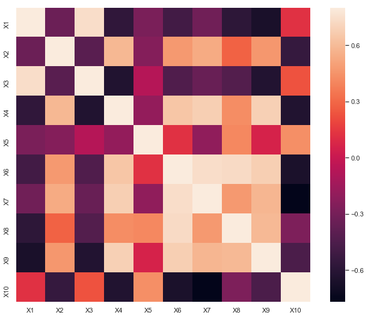

```python
#all credit due to: Pedro Marcelino; https://www.kaggle.com/pmarcelino/comprehensive-data-exploration-with-python
#correlation matrix
corrmat = ds2.corr()
f, ax = plt.subplots(figsize=(12, 9))
sns.heatmap(corrmat, vmax=.8, square=True)
plt.savefig('ds1_correlation_matrix.png',dpi=300, bbox_inches='tight')
```

### 💭👆🏾Just a few thoughts...👆🏾💭

- Looking at this correlation matrix, it's hard to see any definite pattern except that x6-x9 seem to be somehow correlated with one another.

Back to Top

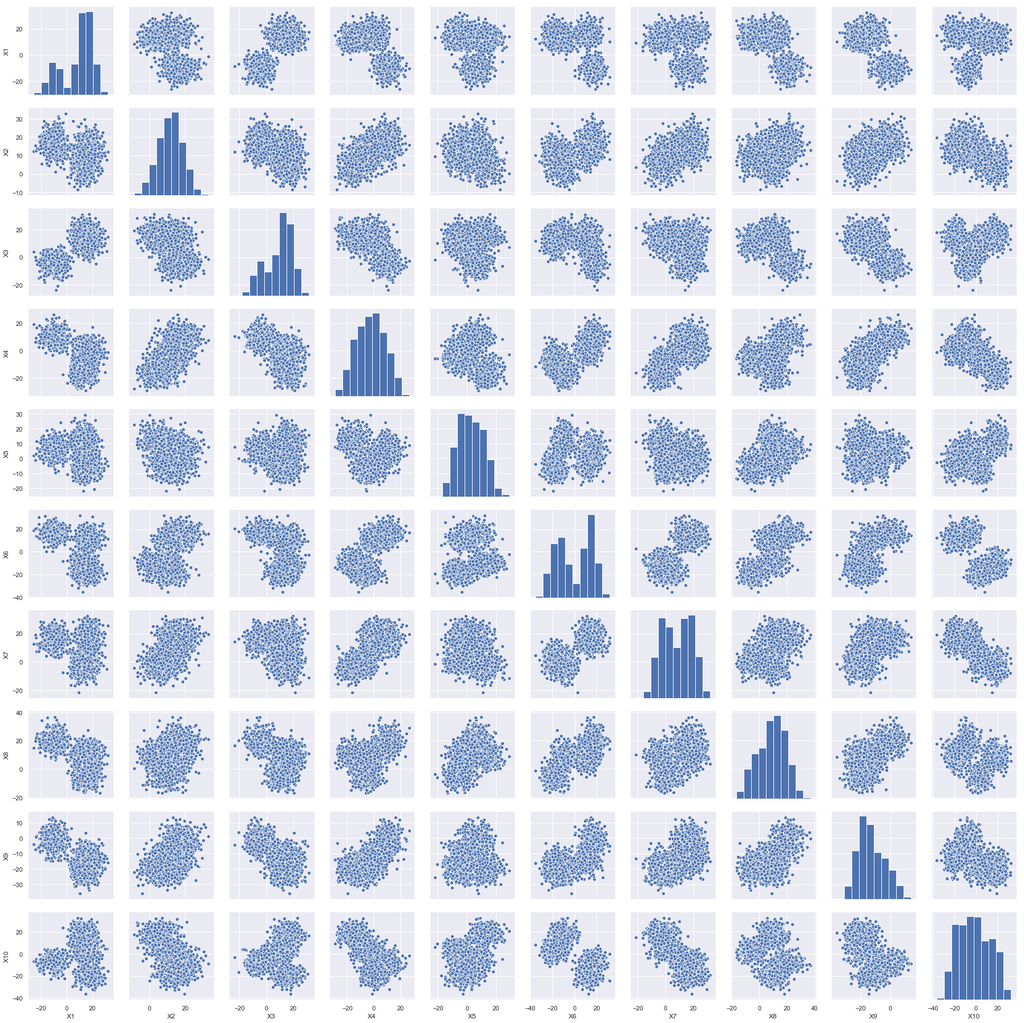

```python
#all credit due to: Pedro Marcelino, https://www.kaggle.com/pmarcelino/comprehensive-data-exploration-with-python
sns.pairplot(ds2, size = 2.5)
plt.show()
```

Back to Top

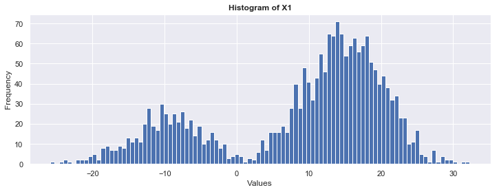

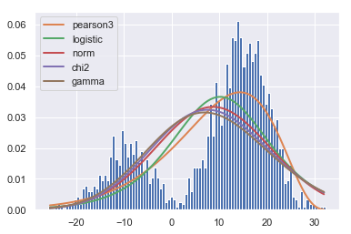

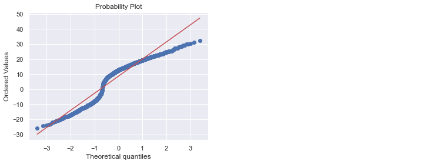

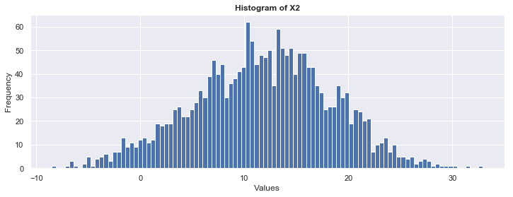

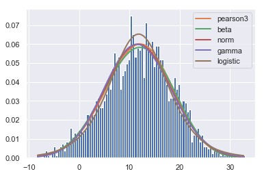

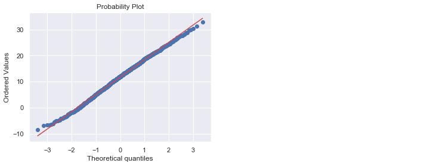

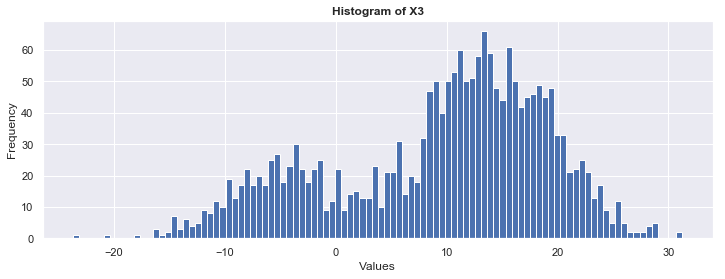

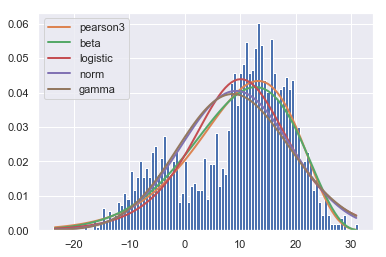

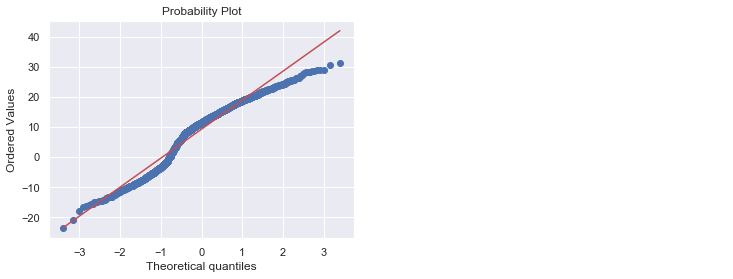

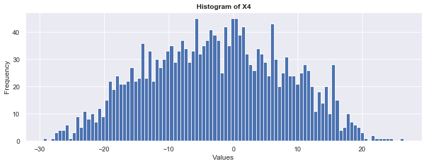

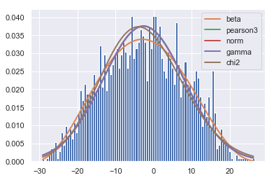

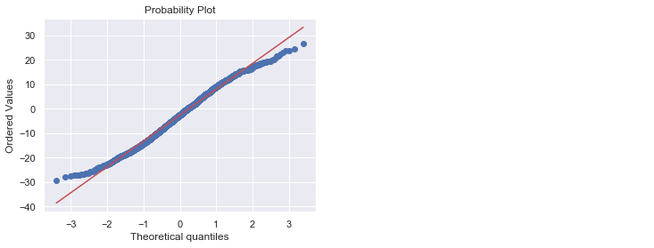

[18 more figures not shown]

```python
#lets also check the distributions again
for i in ds2.columns:
    distribution_visualizer_and_fitter(ds2, i)
```

### 💭👆🏾Just a few thoughts...👆🏾💭

- One thing that immediately jumps out at you is how bi-modal the data is.

Back to Top

## Question 4 - Part II.B

- How would you visualize this data set? Can you make an interesting visualization?

Back to Top

## 👇🏾 Gameplan for Principal Component Analysis (PCA)👇🏾

- The difficult with visualizing data like this, or doing any type of serious unsupervised learning is the high dimensionality.
- As I read somewhere on StackOverflow once, 'do you know anyone who can see in 10D?" 😊
- So what we need to is figure out how to reduce the dimensionality.
- We want to see how few components we need to approximate the cumulative variance.
- Once we reduce the components a bit, we'll be able to tease out insight.
- Once we tease out the insight, we'll be able to visualize it.
  - And, not to give away the next section, but then we can begin to cluster it with K-Means.

Back to Top

### 👇🏾 First thing's first: how many PCA components do we actually need?👇🏾

- The first thing we do is figure out how many components we need to explain most of the variance in this high dimensional dataset.
- I'll show you two methods.
  - One through a standard PCA method. Special thanks to [Bartosz Mikulski](https://github.com/BartMiki) for blogging about it.
  - One through a special Python third-party package. Special thanks to [Andrew Heusser](https://github.com/andrewheusser) for writing it.

```python
#it's important to scale the data so you can compare apples-to-apples how much each component contributes to variance
scaler = MinMaxScaler()
data_rescaled = scaler.fit_transform(ds2)
```

```python
#we'll need to set a variance threshold. I choose 95%; some others my choose 99%; it's up to you.
pca = PCA(n_components = 0.95)
pca.fit(data_rescaled)
reduced = pca.transform(data_rescaled)
```

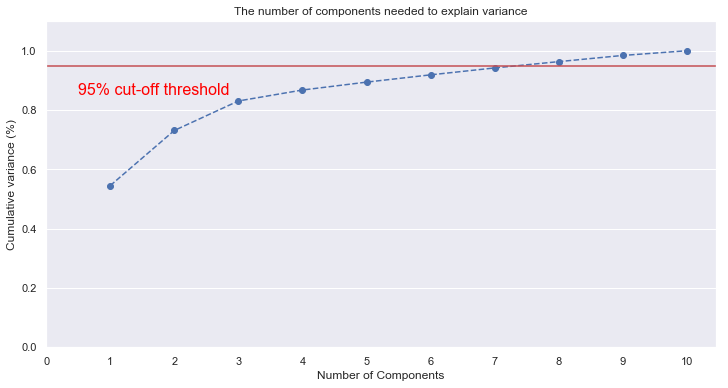

```python
#all credit here to Bartosz Mikulski, https://www.mikulskibartosz.name/pca-how-to-choose-the-number-of-components/
pca = PCA().fit(data_rescaled)

plt.rcParams["figure.figsize"] = (12,6)

fig, ax = plt.subplots()
xi = np.arange(1, 11, step=1)
y = np.cumsum(pca.explained_variance_ratio_)

plt.ylim(0.0,1.1)
plt.plot(xi, y, marker='o', linestyle='--', color='b')

plt.xlabel('Number of Components')
plt.xticks(np.arange(0, 11, step=1)) #change from 0-based array index to 1-based human-readable label
plt.ylabel('Cumulative variance (%)')
plt.title('The number of components needed to explain variance')

plt.axhline(y=0.95, color='r', linestyle='-')
plt.text(0.5, 0.85, '95% cut-off threshold', color = 'red', fontsize=16)

ax.grid(axis='x')
plt.show()
```

### 💭👆🏾Just a few thoughts...👆🏾💭

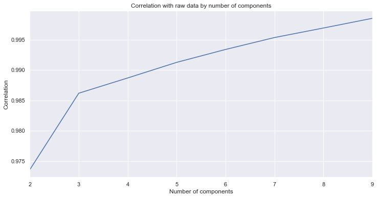

```
{'average': [0.9736018878700515,
  0.9861890676941355,
  0.988700379639046,
  0.9912663044390128,
  0.9933949689870721,
  0.9953561617427169,
  0.9969256847288822,
  0.9985214973696905],
 'individual': [[0.9736018878700515,
   0.9861890676941355,
   0.988700379639046,
   0.9912663044390128,
   0.9933949689870721,
   0.9953561617427169,
   0.9969256847288822,
   0.9985214973696905]]}
```

```python
#there is also a third-party Python plug-in called 'Hypertools' which has a similiar procedure
#it looks to correlation
#the package was written by Andrew Heusser,
#https://hypertools.readthedocs.io/en/latest/auto_examples/plot_describe.html#sphx-glr-auto-examples-plot-describe-py
hyp.describe(ds2)
```

### 💭👆🏾Just a few thoughts...👆🏾💭

- So, we see that 3 components seems to be the magic elbow point.
- Let's see what happens when we graph these 3 components....

Back to Top

### 👇🏾 Second thing's second: let's look at our data in 3D, as opposed to 10D.👇🏾

- Now we will take a look at our first visualization.
- We will set our PCA algorithm to have n_components of 3 after all the work we just did to arrive at that number.
  - It appears that 3 really is [the magic number](https://youtu.be/aU4pyiB-kq0).

```python
pca_execution = PCA(n_components=3)
pca_doing_its_work = pca_execution.fit_transform(data_rescaled)
print("original shape:   ", data_rescaled.shape)
print("transformed shape:", pca_doing_its_work.shape)
```

```
original shape:    (2000, 10)
transformed shape: (2000, 3)
```

```python
pca_conjecture = pd.DataFrame(pca_doing_its_work, columns=['component_1','component_2', 'component_3'])
```

```python
pca_conjecture.head()
```

|  | component_1 | component_2 | component_3 |
| --- | --- | --- | --- |
| 0 | -0.513079 | 0.150428 | 0.069967 |
| 1 | 0.164240 | 0.392656 | -0.071182 |
| 2 | 0.243555 | 0.171085 | -0.136090 |
| 3 | -0.385704 | 0.017588 | 0.252501 |
| 4 | -0.303847 | 0.083962 | 0.351603 |

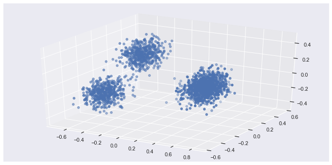

```python
#all credit here to Jake Vanderplas,
#https://jakevdp.github.io/PythonDataScienceHandbook/04.12-three-dimensional-plotting.html
fig = plt.figure()
ax = plt.axes(projection='3d')
ax.scatter3D(pca_conjecture.component_1, pca_conjecture.component_2, pca_conjecture.component_3)
plt.savefig('pca_3D_graph.png',dpi=300, bbox_inches='tight')
```

### 💭👆🏾Just a few thoughts...👆🏾💭

- This is a really cool 3D plot of what how we can group the data.
- Although there are 10(!) dimensions, we can reduce those to basically 3 dimensions.
- Very, very conveniently, the human mind can picture 3 dimensions on a 3D plot.
  - It's very possible to have reduced to components which *still* would not be easily interpreted, so I think we really lucked out here! That's why I say **'The Lord Always Delivers.'** 😊🙏
- Key point: It's tempting to think that this means that all the observations (i.e., the rows) can be split into 3 fields. But we're *not there just yet.*
  - We have basically reduced the columns in this gigantic data set from 10 to 3, but we now will want to figure out how to apply K-Means clustering to find out more.
- Note: K-Means begins to break down at high dimensions because of what's called 'the curve of dimensionality,'
  - Basically, anything that uses Euclidean distance is going to get a lot less meaningful because dimensions will begin to make everything potentially close to everything else when you combine it all to one vector. Therefore, it helps to reduce the components first.
    - Also, please note: There are other clustering methods that can perform better with high dimensionality, but that's outside the scope of this notebook. If you are curious, [more info here](https://scikit-learn.org/stable/modules/clustering.html).

Back to Top

## Question 5 - Part II.C

- Someone suggests that the observations are really from multiple different files and were accidentally joined into one larger data set. Does anything about the data set suggest this? If so, how many different sources/file do you think there are?

Back to Top

### 👇🏾 We begin our K-Means Clustering analysis now we've completed the PCA round.👇🏾

- Let the K-Means games begin!
- The first rule of thumb is to use an algorithm to choose you n clusters for K means.
- It's tempting to just jump right in and use the number 3 from before, but we will want to evaluate an **'elbow'** graph again.
  - By the way, in case you are curious, I actually tested K-means on the PCA-generated dataframe framework offline, and 3 was **not** the optimum number of K clusters.

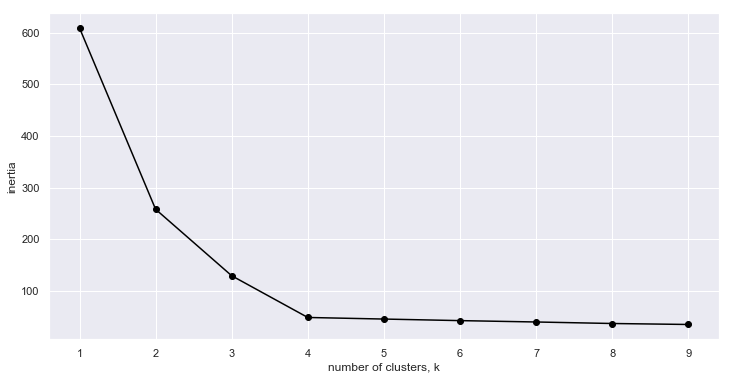

```python
#all credit to Dmitriy Kavyazin, http://bit.ly/2mYDWv7
ks = range(1, 10)
inertias = []
for k in ks:
    # Create a KMeans instance with k clusters: model
    model = KMeans(n_clusters=k)

    # Fit model to samples
    model.fit(pca_conjecture) #.iloc[:,:3])

    # Append the inertia to the list of inertias
    inertias.append(model.inertia_)

plt.plot(ks, inertias, '-o', color='black')
plt.xlabel('number of clusters, k')
plt.ylabel('inertia')
plt.xticks(ks)
plt.show()
```

### 💭👆🏾Just a few thoughts...👆🏾💭

- So we can actually see the elbow point comes at **4** clusters!!! ✅🙏
- Let's go ahead and plot that next!!

```python
#here comes K-Means at long last!
kmeans = KMeans(n_clusters=4)
kmeans.fit(pca_conjecture)
choice_kmeans = kmeans.predict(pca_conjecture)
```

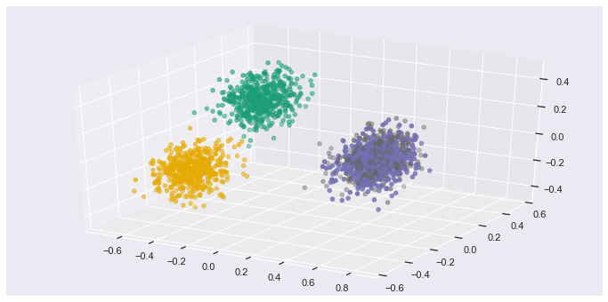

```python
fig = plt.figure()
ax = plt.axes(projection='3d')
ax.scatter3D(pca_conjecture.component_1, pca_conjecture.component_2, pca_conjecture.component_3,\
             c=choice_kmeans, cmap='Dark2')
plt.savefig('kmeans_on_pca.png',dpi=300, bbox_inches='tight')
```

### 💭👆🏾Just a few thoughts...👆🏾💭

- And voilà: now we have a great visualization of the 10D data.
- We can see that there are basically **3 principal components (the blobs)** and **4 cohorts (the colors)** the actual observations can be sorted into.
  - In future analysis, we'll want to study why 2 cohorts seem to get jammed into 1 component, yet they are not themselves considered the same cohort.
    - We'll want to better understand what factors K-Means() is using to differentiate them.

Back to Top

## Question 6 - Part II.D - Bonus

- Bonus points: If you think there are more than one source in ds2, can you assign each observation to the right source (based on the number of sources you identified in 2c)?

### 👇🏾 Applying our K-means work from the last question...👇🏾

- We can simply take the same K-Means classifications we used to make the hues in the 3D plot above, and apply them to the ds2 dataframe.

```python
#just to be safe, we can check the shape so we know that they'll match
print(ds2.shape)
print(choice_kmeans.shape)
```

```
(2000, 10)
(2000,)
```

```python
ds2['cohort_guess'] = choice_kmeans
```

```python
ds2.sample(10)
```

|  | X1 | X2 | X3 | X4 | X5 | X6 | X7 | X8 | X9 | X10 | cohort_guess |
| --- | --- | --- | --- | --- | --- | --- | --- | --- | --- | --- | --- |
| 856 | 16.258705 | 7.536404 | 20.738980 | -12.694768 | 2.361967 | -13.735497 | 1.114422 | 7.757069 | -11.394184 | 21.557510 | 2 |
| 1107 | -3.724744 | 16.132432 | -6.568144 | 9.931925 | 2.570133 | 15.679603 | 8.533902 | 15.854891 | -3.841659 | -2.757685 | 1 |
| 992 | 7.901057 | 11.937911 | 13.580849 | -4.198245 | -1.866585 | -22.293985 | -0.826338 | -6.077889 | -15.110786 | 5.361091 | 0 |
| 1297 | -9.897615 | 25.005272 | -9.610588 | 18.815536 | 6.059984 | 22.159695 | 29.886364 | 19.724171 | -3.086989 | -4.117812 | 1 |
| 445 | 18.250491 | 17.457891 | 18.771506 | -0.833597 | -13.159148 | 9.135771 | 21.157722 | 11.466289 | -5.570972 | -17.053007 | 3 |
| 183 | -10.539711 | 15.283469 | -11.576097 | 9.137384 | 2.902189 | 15.165293 | 20.014466 | 19.858354 | 5.253761 | -18.449395 | 1 |
| 1411 | -5.274538 | 21.802477 | -10.129634 | 2.056461 | 1.218785 | 12.577448 | 20.278365 | 19.309603 | 2.381341 | -12.527796 | 1 |
| 1161 | 12.363580 | 7.115654 | 16.053999 | -1.434357 | 5.038282 | -18.648144 | 4.398782 | -7.789061 | -13.777822 | 10.110424 | 0 |
| 873 | 8.534240 | 4.586206 | 10.560645 | -19.470090 | 15.850141 | -6.419461 | -2.522902 | 9.986515 | -17.717444 | 20.802697 | 2 |
| 1348 | 8.210770 | -3.624457 | 4.939408 | -5.635591 | 21.514586 | -10.027645 | -1.592554 | 9.510031 | -20.588316 | 15.208638 | 2 |

### 💭👆🏾Just a few thoughts...👆🏾💭

- And there we have it!
- I took a sample of the dataframe instead of the head() method, so you can get an idea of the different 'cohort guesses'.
- You can see that there are 4 different K-Means cohorts now.
  - 0, 1, 2, and 3
- I would argue that these are where the disparate files came from before they were joined in ds2.

Back to Top

# Part III. - SQL Coding

- Stack Overflow provides a tool at https://data.stackexchange.com/stackoverflow/query/new that allows SQL queries to be run against their data. After reviewing the database schema provided on their site, please answer the questions below by providing both your answer and the query used to derive it.

### 👇🏾 Full answers and clickable/runable results can be found on the Stack Overflows query permalink.👇🏾¶

### http://bit.ly/2mJ5nct

Back to Top

## Question 7 - Part III.A

- How many posts were created in 2017?
  - Stack Overflow Query Permalink:
    - http://bit.ly/2mJ5nct

[figure not shown]

```python
query_3_a_results = pd.read_csv('stackoverflow_query_3-a_results.csv')
query_3_a_results
```

|  | Num_Posts_2017 |
| --- | --- |
| 0 | 5062160 |

Back to Top

## Question 8 - Part III.B

- What is the distribution of views for users?
  - Stack Overflow Query Permalink:
    - http://bit.ly/2mJ5nct

[figure not shown]

```python
query_3_b_results = pd.read_csv('stackoverflow_query_3-b_results.csv')
query_3_b_results.head(10)
```

|  | View_Level | Frequency |
| --- | --- | --- |
| 0 | 0 | 6014518 |
| 1 | 1 | 1317265 |
| 2 | 2 | 725275 |
| 3 | 3 | 466790 |
| 4 | 4 | 326298 |
| 5 | 5 | 242879 |
| 6 | 6 | 188453 |
| 7 | 7 | 151391 |
| 8 | 8 | 125166 |
| 9 | 9 | 105231 |

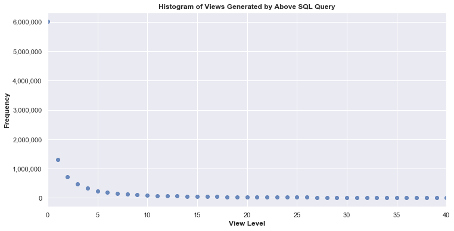

```python
ax = sns.regplot(x="View_Level", y="Frequency", data=query_3_b_results, fit_reg=False)
ax.set_ylabel('Frequency', fontweight = 'bold')
ax.set_xlim(0,40)
ax.set_xlabel("View Level", fontweight = 'bold')
ax.yaxis.set_major_formatter(mpl.ticker.StrMethodFormatter('{x:,.0f}'))
ax.set_title("Histogram of Views Generated by Above SQL Query", fontweight = 'bold')
plt.show()
```

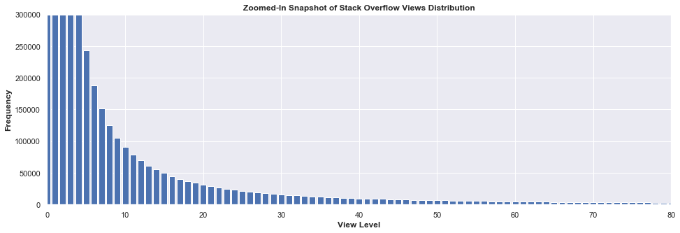

```python
plt.figure(figsize=(16,5))
plt.bar(query_3_b_results.View_Level, query_3_b_results.Frequency)
plt.ylim(0,300000)
plt.xlim(0,80)
plt.title("Zoomed-In Snapshot of Stack Overflow Views Distribution", fontweight='bold')
plt.ylabel("Frequency", fontweight = 'bold')
plt.xlabel("View Level", fontweight = 'bold')
plt.show()
```

Back to Top

## Question 9 - Part III.C

- What are the top 10 tags associated with posts created in 2017?
  - Stack Overflow Query Permalink:
    - http://bit.ly/2mJ5nct

[figure not shown]

```python
query_3_c_results = pd.read_csv('stackoverflow_query_3-c_results.csv')
query_3_c_results
```

|  | Tag | Tag_Count |
| --- | --- | --- |
| 0 | javascript | 250807 |
| 1 | python | 192652 |
| 2 | java | 175109 |
| 3 | php | 142844 |
| 4 | android | 136363 |
| 5 | c# | 132168 |
| 6 | html | 109411 |
| 7 | jquery | 92614 |
| 8 | css | 75326 |
| 9 | ios | 66249 |

Back to Top

## Question 10 - Part III.D - Bonus

- Bonus points: For the questions created in 2017, what was the average time (in seconds) between when the question was created and when the accepted answer was provided?
  - Stack Overflow Query Permalink:
    - http://bit.ly/2mJ5nct

[figure not shown]

```python
query_3_d_bonus_results = pd.read_csv('stackoverflow_query_3-d_results.csv')
query_3_d_bonus_results
```

|  | Avg_Response_Secs |
| --- | --- |
| 0 | 201332 |

Back to Top

# Thank you so much for your time and consideration!

## George John Jordan Thomas Aquinas Hayward, Optimist

[figure not shown]

[#TheLordAlwaysDelivers](https://youtu.be/in2MOJ-Hb8g)